# Data Wrangling for EDSDers

8-11 Nov, 2021 Tim Riffe Universidad del País Vasco & Ikerbasque (Basque Foundation for Science)

10 Nov, 2021

# 1 Introduction

In this script weŕe going to combine a demographic dataset (World Population Prospects) with a sociological dataset (World Value Survey). Both cover a range of years and either all or most countries of the world. In order to join the two datasets we’ll need to do do some pre-harmonization in order to get them joinable. This will consist in getting both datasets tidy, giving consistently named and coded columns on which to join them.

Packages we’ll use:

```r
library(here)
library(tidyverse)
library(wpp2019)
```

# 2 World Value Survey (WVS)

We’ll start by prepping the WVS Inglehart et al. (2014). Download the WVS **Longitudinal** file from here: http://www.worldvaluessurvey.org/, which ships in 4 different data formats, including `.rds`! Download it too, and **unzip** it in the `Data` folder for this project. Let’s see what’s inside.

The data consist in individual respondents as the unit of observation, and we’ll want to get an aggregate out of it. We need to do the following operations to WVS in order to get it joinable:

1. We need to browse the documentation to figure out what variable to focus on. Ideally available in most of the individual surveys (we’ll check it’s mostly not missing)
2. Age should either be in clean single ages or clean grouped ages. For simplicity we’ll use 5-year age groups since WPP is already in that form.
3. We need harmonized years. WPP gives 5-year intervals whereas WVS gives exact years. I suggest we year-group the WVS data inot 5-year bins.
4. We need to get some sort of prevalence or mean measure per 5-year age group in some interesting variable (by year, age, sex and country). We can do this using the `summarize()` function instead of regression. Regression would be better though because we’d be able to smooth and impute missing ages.

Here we read in the data, which we downloaded already in one of `R`’s native formats (`.rds`). By the way you can save an object in this format using `saveRDS()`. At this point we were also browsing the spreadsheet that comes with the data. We need that spreadsheet to know which columns to grab, since they’re just alphanumeric codes.

```r
WVS <- readRDS(
  here::here("Data",
             "F00008390-WVS_Longitudinal_1981_2016_r_v20180912.rds"))
#colnames(WVS)
# country code
unique(WVS$S003)
```

```
##   [1]  32  36 246 348 392 484 710 410 752 840 112  76 203 152 156 356 566 616 643 703 724 756 792   8  51  31  50 914 100 170 191 214 222 233 268
##  [36] 276 826 428 440 807 498 499 554 578 586 604 608 630 642 688 705 101 158 804 858 862  12  70 124 818 360 364 368 376 400 417 504 682 702 834
##  [71] 800 704 716  20 854 196 231 250 288 320 344 380 458 466 528 646 764 780 894 218 332 398 414 422 434 275 634 788 860 887
```

```r
# year
unique(WVS$S020)
```

```
##  [1] 1984 1981 1982 1991 1990 1989 1998 1995 1997 1996 1999 1994 2002 2001 2000 2004 2003 2005 2006 2007 2008 2009 2014 2013 2011 2012 2016 2010
```

```r
# sex
unique(WVS$X001)
```

```
## [1]  2  1 -4 -2 -1 -5
```

```r
# age
sort(unique(WVS$X003))
```

```
##  [1]  -5  -4  -3  -2  -1  13  14  15  16  17  18  19  20  21  22  23  24  25  26  27  28  29  30  31  32  33  34  35  36  37  38  39  40  41  42  43
## [37]  44  45  46  47  48  49  50  51  52  53  54  55  56  57  58  59  60  61  62  63  64  65  66  67  68  69  70  71  72  73  74  75  76  77  78  79
## [73]  80  81  82  83  84  85  86  87  88  89  90  91  92  93  94  95  96  97  98  99 102
```

```r
# A015 "People can be trusted"
table(WVS$A165)
```

```
##
##     -5     -4     -2     -1      1      2
##    148   2988   3319   9755  87723 244599
```

```r
# S017 person weight (any will do for this exercise)
```

Select ISO, Year, Age, Sex, Person Weight, Trust. `select()` can also be used to rename at the same time, it turns out, so we can turn this thing into a friendly dataset very quickly. The next step removes cases with missings (we checked and there weren’t enough missings to cause worry). Then we recode (overwrite) year and age to conform to 5-year AP Lexis cells. Having done that, we’re now set to tabulate in the final step of the pipe. It’s a raw tabulation consisting in weighted means of the variable we picked out. The result gets a prevalence interpretation because it’s between 0 and 1 and has a clear meaning like that.

```r
WVS <-
  WVS %>%
  # remove variable labels
  zap_labels() %>%
  # grab variables we need
  select(ISO = S003,
         year = S020, # Year
         sex = X001, # Sex
         age = X003, # age
         trust = A165,
         pwt = S017) %>%  # trust
  #pull(sex) %>% table() # spot check for negative age
  # remove missings, nothing fancy here, and no
  # reason to get hung up on it.
  filter(age >= 0,
         trust > 0,
         sex > 0) %>%
  # bin to 5-year Lexis cells, recoded trust
  mutate(year = year - year %% 5,
         age = age - age %% 5,
         distrust = trust - 1,
         trust = 1 - distrust) %>%
  # tabulate (two steps)
  group_by(ISO, sex, year, age) %>%
  summarize(trust = sum(trust * pwt) / sum(pwt),
            distrust = sum(distrust * pwt) / sum(pwt),
            .groups = "drop")%>%
  sjlabelled::remove_all_labels()
```

# 3 World Population Prospects (WPP)

The UN uses the same country codes, and ships its data as aggregates in a different shape altogether: almost tidy, but with years going out in the columns. From the `wpp2019` Division (2019). This package consists in a bunch of datasets, including denominators, rates, and indices. We opted to calculate a Sullivan estimate of trust expectancy, and for this we’ll want lifetable exposure `nLx`, which isn’t included in the package. We can calculate it from `nMx`, however, which is available in two datasets: `mxF` and `mxM`. We can load them into memory by calling `data(mxF)`, for example.

```r
#install.packages("wpp2019")
data(mxF)
data(mxM)
# glimpse(mxF)
# check country code overlap, not bad!
intersect(unique(mxF$country_code),unique(WVS$ISO))
```

```
##  [1] 231 646 800 834 894 716 710 914 854 288 466 566  12 818 434 504 788  51  31 196 268 368 376 400 414 422 634 682 275 792 887 398 417 860  50 356
## [37] 364 586 156 344 158 392 410 360 458 608 702 764 704 214 332 630 780 222 320 484  32  76 152 170 218 604 858 862  36 554 112 100 203 348 616 498
## [73] 642 643 703 804 233 246 428 440 578 752 826   8  70 191 380 499 807 688 705 724 250 276 528 756 124 840
```

The first step will be to `rbind()` the two datasets, but in order to do so we need to add a `sex` column to each of them. Looking ahead to our planned merge, let’s take care to code males and females in the same way we left them from WVS.

```r
# add sex column to both datasets
mxF <- mxF %>%
  mutate(sex = 2)
mxM <- mxM %>%
  mutate(sex = 1)
# bind two sexes together
mxT <- rbind(mxF, mxM)
```

Now we’re ready for the WPP pipeline, which will include some lifetable calculations. Some of them fit cleanly into `mutate()` and others are nicer to wrap in helper function like this one, which can also be used inside `mutate()`

```r
px_to_lx <- function(px){
  n <- length(px)
  c(1,cumprod(px)[-n])
}
```

This pipeline has several key steps: first we use `pivot_longer()` to stack years. In the first iteration we had `cols = 4:33`, which identifies the columns to stack by integer column positions, but I’ve now changed it to take a continuous name range. The `1950-1955` is in back-ticks because otherwise it’d get misinterpreted as a numeric thing. We next use a string operation to extract the lower year bound. There are different ways we could do this, but decided to use a `substr()`. For example `subtr("Timothy", start = 1, stop = 3)` would return `"Tim"`. Inside the same `mutate()` call we do more stuff, we next define an instrumental lifetable column `AgeInt` that holds the width of age classes (we’re in a standard abridged lifetable), and for that we use `case_when()`. Assuming deaths happen on average halfway through the interval (this is awful), we define the lifetable `nAx` column. With knowledge of `nMx` and `nAx` we can follow standard abridged lifetable (Preston, Heuveline, and Guillot 2000) formulas to get `nqx`, in which case we’re ready to roll into lifetable calcs. The pipe description continues below the chunk.

```r
# send it down the pipe
mxT <-
  mxT %>%
  pivot_longer(cols =`1950-1955`:`2095-2100`,
               names_to = "year",
               values_to = "nMx") %>%
  mutate(year = substr(year,
                       start = 1,
                       stop = 4),
         year = as.integer(year),
         # in a case_when go from the
         # specific to the general
         AgeInt = case_when(
           age == 0 ~ 1,
           age == 1 ~ 4,
           TRUE ~ 5 # catch-all
         ),
         # midpoint assumption for nAx
         nAx = AgeInt / 2,
         # risky qx formula (could go outside [0,1].
         # formula from Preston book
         qx = ifelse(age == 100,
                     1,
                     (AgeInt * nMx) /
           (1 + (AgeInt - nAx) * nMx))) %>%
  arrange(country_code, sex, year, age) %>%
  group_by(country_code, sex, year) %>%
  mutate(px = 1 - qx,
         lx = px_to_lx(px),
         ndx = qx * lx,
         nLx = ndx / nMx) %>%
  ungroup() %>%
  rename(ISO = country_code) %>%
  filter(year >= 1980,
         year <= 2015)
```

In the middle of the pipe we see a step `arrange()`. This function sorts rows according to the variables listed from left to write. We needed to put this here because we needed `year` to be numeric for proper sorting. We need the sorting because some lifetable calculations are sequentially dependent within age. After the sorting operation, we continue lifetables *within* subsets (ergo `group_by() + mutate()`), including our above-defined helper function `px_to_lx()`, and we needn’t go further than `nLx`. Finally let’s standardize one last column name and select only those years that fall within the WVS range.

Now we’re ready to do our join operation. Look at how much overhead was needed in order to turn these two datasets into joinable things!! The lesson: you need to have 1) identically named and 2) identically coded columns on which to join. It would have been a heck of alot easier to join if we only needed to join on ISO codes! But hey, we have super awesome detailed and nested demographic data that we wish to preserve in the name of science.

# 4 The join

Here’s the join operation. Remember we looked at the `dplyr` [Data Wrangling Cheat Sheet](https://rstudio.com/wp-content/uploads/2015/02/data-wrangling-cheatsheet.pdf) to figure out which merge operation to do.

```r
mxT <- left_join(
  mxT,
  WVS,
  by = c("ISO","sex","year","age"))
```

# 5 Final cleaning and fun

We need a helper function whose job it is to replace NAs with the average of neighboring cells.

```r
na_averager <- function(age, prev){
  ind <- is.na(prev)
  # if nothing is missing just return prev
  if (all(!ind)){
    return(prev)
  }
  # otherwise we need to do this
  approx(x = age[!ind],
         y = prev[!ind],
         xout = age,
         rule = 2)$y
}
# x <- c(15,20,25,30,35,40)
# y <- c(NA,.3,NA,.5,.6,NA)
# na_averager(age=x, prev = y)
```

We now start the semifinal pipeline to parse down and fill out these data. To remove superfluous lifetables, we ask for each lifetables subset (`group_by()`) whether it’s the case that each value of `trust` is an `NA` (`remove`). Then we immediately throw those cases out (`filter()`). Then we impute *occassional* `NA`s using our simple helper function `na_averager()`. By the way, we wouldn’t need to do that if prevalence had been modeled in the first place, as we could have ensured a full age range. Finally, we can calculate our summary index of trusty life expectancy at age 15 `e15trust` (and its complement).

```r
eTrust <-
  mxT %>%
  group_by(ISO, sex, year) %>%
  mutate(remove = all(is.na(trust))) %>%
  ungroup() %>%
  filter(!remove,
         age >= 15) %>%
  group_by(ISO, sex, year) %>%
  mutate(trust = na_averager(age,
                             prev = trust),
         distrust = 1 - trust) %>%
  summarize(e15trust = sum(nLx * trust) /
                           lx[age == 15],
            e15distrust = sum(nLx * distrust) /
                           lx[age == 15],
            .groups = "drop")
```

Note: dividing out `l15` is how we age condition the lifetable. It simply scales up `sum(Lx * trust)`. We may as well cap this off with a visualization of some kind. This is weird, but I propose *trust compression*, i.e. $e_{15}^{trust} / e_{15}$, i.e. on average what fraction of life is spent trustful. This is pure silliness, but the calculations are basically valid. So here we plot life expectancy in x and trust compression in y. Maybe longer lives go along with a larger fraction of life in trustfulness?

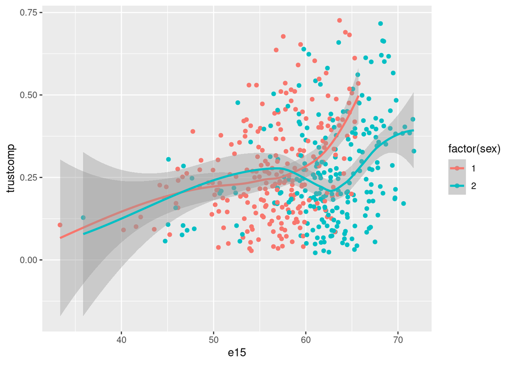

```r
eTrust %>%
  mutate(e15 = e15trust + e15distrust,
         trustcomp = e15trust / e15) %>%
  ggplot(mapping = aes(x = e15,
                       y = trustcomp,
                       color = factor(sex))) +
  geom_point() +
  geom_smooth()
```

# References

Division, United Nations Population. 2019. *Wpp2019: World Population Prospects 2019*. https://CRAN.R-project.org/package=wpp2019.

Inglehart, C, R., A. Moreno Haerpfer, C. Welzel, K. Kizilova, J. Diez-Medrano, M. Lagos, P. Norris, E. Ponarin, and B. Puranen et al. 2014. “World Values Survey: All Rounds - Country-Pooled Datafile.” electronic. http://www.worldvaluessurvey.org/WVSDocumentationWVL.jsp.

Preston, S, Patrick Heuveline, and Michael Guillot. 2000. *Demography: Measuring and Modeling Population Processes. 2001*. Malden, MA: Blackwell Publishers.